# Data Mining - H4

## Association rules for grocery purchases

```
## transactions as itemMatrix in sparse format with
##  9835 rows (elements/itemsets/transactions) and
##  169 columns (items) and a density of 0.02609146
##
## most frequent items:
##       whole milk other vegetables       rolls/buns             soda
##             2513             1903             1809             1715
##           yogurt          (Other)
##             1372            34055
##
## element (itemset/transaction) length distribution:
## sizes
##    1    2    3    4    5    6    7    8    9   10   11   12   13   14   15   16
## 2159 1643 1299 1005  855  645  545  438  350  246  182  117   78   77   55   46
##   17   18   19   20   21   22   23   24   26   27   28   29   32
##   29   14   14    9   11    4    6    1    1    1    1    3    1
##
##    Min. 1st Qu.  Median    Mean 3rd Qu.    Max.
##   1.000   2.000   3.000   4.409   6.000  32.000
##
## includes extended item information - examples:
##             labels
## 1 abrasive cleaner
## 2 artif. sweetener
## 3   baby cosmetics
```

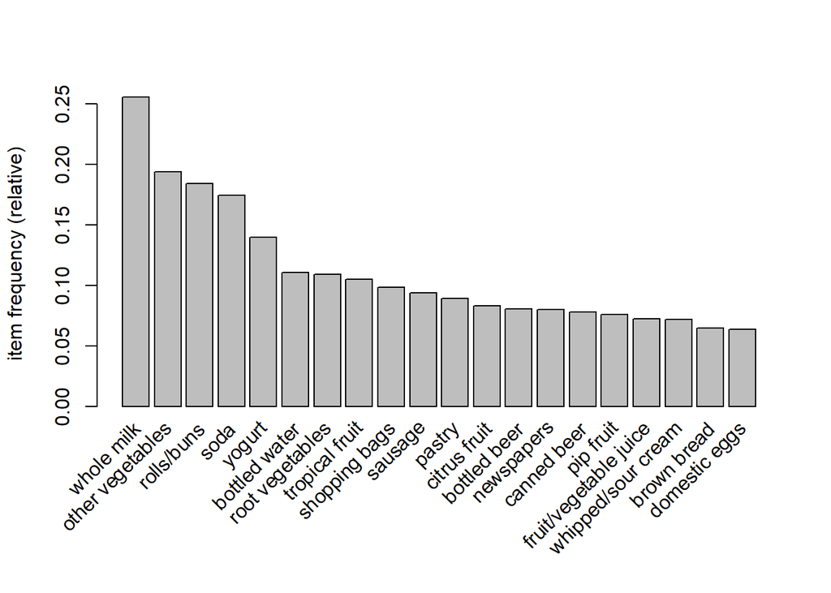

The summary of the groceries.txt file above shows that there are 9835 baskets (shopping lists) that encompass 169 items, the most frequent of which are whole milk, other vegetables, rolls/buns, soda, and yogurt. We see that the distribution of baskets decrease as basket lengths increase, up to a basket of 32 items. There is a mean number of items per basket at 4.409 and a median of 3.

In addition, the plot above shows a distribution of the relative item frequency for the twenty most common items in baskets. We see that these items are generally common grocery items such as food and drinks. These two pieces of information indicates that among the rules to be discovered, the ones with the highest confidence, support, and lift will most likely have common grocery items.

```
## Apriori
##
## Parameter specification:
##  confidence minval smax arem  aval originalSupport maxtime support minlen
##         0.1    0.1    1 none FALSE            TRUE       5   0.005      1
##  maxlen target  ext
##      10  rules TRUE
##
## Algorithmic control:
##  filter tree heap memopt load sort verbose
##     0.1 TRUE TRUE  FALSE TRUE    2    TRUE
##
## Absolute minimum support count: 49
##
## set item appearances ...[0 item(s)] done [0.00s].
## set transactions ...[169 item(s), 9835 transaction(s)] done [0.00s].
## sorting and recoding items ... [120 item(s)] done [0.00s].
## creating transaction tree ... done [0.00s].
## checking subsets of size 1 2 3 4 done [0.00s].
## writing ... [1582 rule(s)] done [0.00s].
## creating S4 object  ... done [0.00s].
```

```
## set of 1582 rules
##
## rule length distribution (lhs + rhs):sizes
##   1   2   3   4
##   8 755 771  48
##
##    Min. 1st Qu.  Median    Mean 3rd Qu.    Max.
##   1.000   2.000   3.000   2.543   3.000   4.000
##
## summary of quality measures:
##     support           confidence        coverage             lift
##  Min.   :0.005084   Min.   :0.1000   Min.   :0.008134   Min.   :0.4457
##  1st Qu.:0.005897   1st Qu.:0.1454   1st Qu.:0.022979   1st Qu.:1.4732
##  Median :0.007321   Median :0.2189   Median :0.037112   Median :1.8174
##  Mean   :0.010537   Mean   :0.2557   Mean   :0.053306   Mean   :1.9028
##  3rd Qu.:0.010371   3rd Qu.:0.3315   3rd Qu.:0.058058   3rd Qu.:2.2444
##  Max.   :0.255516   Max.   :0.7000   Max.   :1.000000   Max.   :4.6399
##      count
##  Min.   :  50.0
##  1st Qu.:  58.0
##  Median :  72.0
##  Mean   : 103.6
##  3rd Qu.: 102.0
##  Max.   :2513.0
##
## mining info:
##       data ntransactions support confidence
##  groceries          9835   0.005        0.1
##                                                                            call
##  apriori(data = groceries, parameter = list(support = 0.005, confidence = 0.1))
```

By choosing the thresholds for support = 0.005 and confidence = 0.1, we generate a set of 1582 rules with the highest order of 4. Our summary of quality measures show reasonable values given the dataset. For example, we see a max support of 0.256, max confidence of 0.7, max coverage of 1, max lift of 4.64, and a max count of 2513. Median and mean values also seem reasonable.

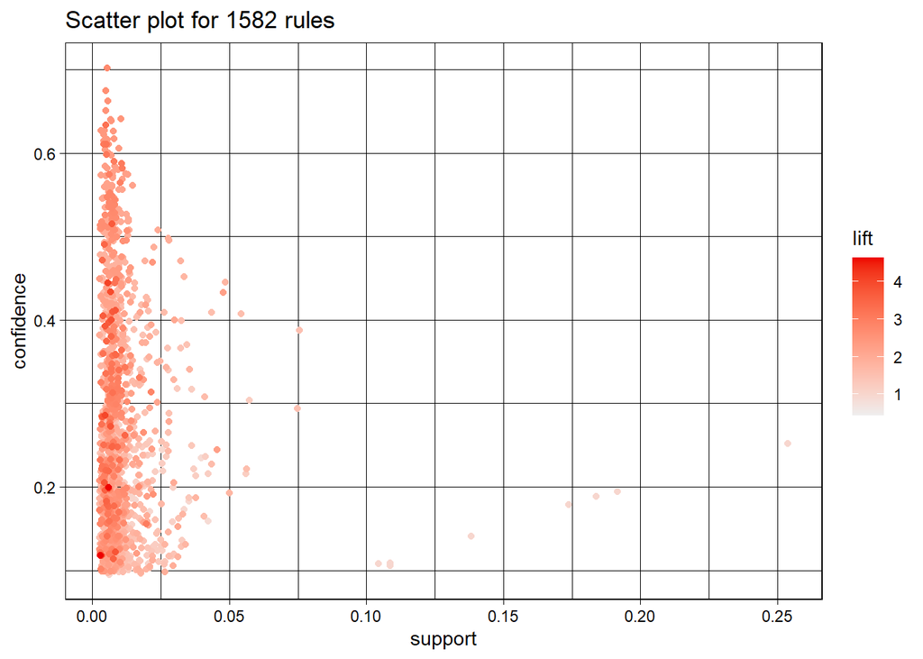

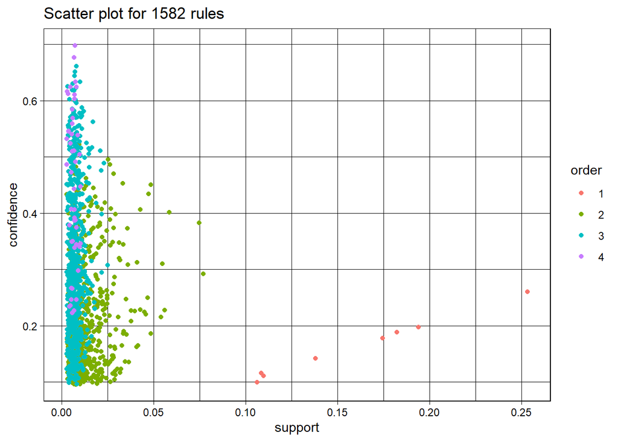

```
##      lhs                   rhs                support    confidence coverage
## [1]  {}                 => {whole milk}       0.25551601 0.2555160  1.0000000
## [2]  {}                 => {other vegetables} 0.19349263 0.1934926  1.0000000
## [3]  {}                 => {rolls/buns}       0.18393493 0.1839349  1.0000000
## [4]  {}                 => {soda}             0.17437722 0.1743772  1.0000000
## [5]  {}                 => {yogurt}           0.13950178 0.1395018  1.0000000
## [6]  {}                 => {bottled water}    0.11052364 0.1105236  1.0000000
## [7]  {}                 => {root vegetables}  0.10899847 0.1089985  1.0000000
## [8]  {}                 => {tropical fruit}   0.10493137 0.1049314  1.0000000
## [9]  {other vegetables} => {whole milk}       0.07483477 0.3867578  0.1934926
## [10] {whole milk}       => {other vegetables} 0.07483477 0.2928770  0.2555160
##      lift     count
## [1]  1.000000 2513
## [2]  1.000000 1903
## [3]  1.000000 1809
## [4]  1.000000 1715
## [5]  1.000000 1372
## [6]  1.000000 1087
## [7]  1.000000 1072
## [8]  1.000000 1032
## [9]  1.513634  736
## [10] 1.513634  736
```

```
##      lhs                     rhs                    support confidence    coverage     lift count
## [1]  {root vegetables,
##       tropical fruit,
##       yogurt}             => {whole milk}       0.005693950  0.7000000 0.008134215 2.739554    56
## [2]  {other vegetables,
##       pip fruit,
##       root vegetables}    => {whole milk}       0.005490595  0.6750000 0.008134215 2.641713    54
## [3]  {butter,
##       whipped/sour cream} => {whole milk}       0.006710727  0.6600000 0.010167768 2.583008    66
## [4]  {pip fruit,
##       whipped/sour cream} => {whole milk}       0.005998983  0.6483516 0.009252669 2.537421    59
## [5]  {butter,
##       yogurt}             => {whole milk}       0.009354347  0.6388889 0.014641586 2.500387    92
## [6]  {butter,
##       root vegetables}    => {whole milk}       0.008235892  0.6377953 0.012913066 2.496107    81
## [7]  {curd,
##       tropical fruit}     => {whole milk}       0.006507372  0.6336634 0.010269446 2.479936    64
## [8]  {citrus fruit,
##       root vegetables,
##       whole milk}         => {other vegetables} 0.005795628  0.6333333 0.009150991 3.273165    57
## [9]  {other vegetables,
##       pip fruit,
##       yogurt}             => {whole milk}       0.005083884  0.6250000 0.008134215 2.446031    50
## [10] {domestic eggs,
##       pip fruit}          => {whole milk}       0.005388917  0.6235294 0.008642603 2.440275    53
```

```
##      lhs                     rhs                      support confidence   coverage     lift count
## [1]  {ham}                => {white bread}        0.005083884  0.1953125 0.02602949 4.639851    50
## [2]  {white bread}        => {ham}                0.005083884  0.1207729 0.04209456 4.639851    50
## [3]  {citrus fruit,
##       other vegetables,
##       whole milk}         => {root vegetables}    0.005795628  0.4453125 0.01301474 4.085493    57
## [4]  {butter,
##       other vegetables}   => {whipped/sour cream} 0.005795628  0.2893401 0.02003050 4.036397    57
## [5]  {herbs}              => {root vegetables}    0.007015760  0.4312500 0.01626843 3.956477    69
## [6]  {other vegetables,
##       root vegetables}    => {onions}             0.005693950  0.1201717 0.04738180 3.875044    56
## [7]  {citrus fruit,
##       pip fruit}          => {tropical fruit}     0.005592272  0.4044118 0.01382816 3.854060    55
## [8]  {berries}            => {whipped/sour cream} 0.009049314  0.2721713 0.03324860 3.796886    89
## [9]  {whipped/sour cream} => {berries}            0.009049314  0.1262411 0.07168277 3.796886    89
## [10] {other vegetables,
##       tropical fruit,
##       whole milk}         => {root vegetables}    0.007015760  0.4107143 0.01708185 3.768074    69
```

The three tables above show the top ten rules sorted by support, confidence, and lift, respectively. These tables confirm our previous hunch that the top performing rules will generally contain common grocery items such as food and drinks.

```
##      lhs                         rhs                         support confidence    coverage     lift count
## [1]  {herbs}                  => {root vegetables}       0.007015760  0.4312500 0.016268429 3.956477    69
## [2]  {ham}                    => {white bread}           0.005083884  0.1953125 0.026029487 4.639851    50
## [3]  {white bread}            => {ham}                   0.005083884  0.1207729 0.042094560 4.639851    50
## [4]  {sliced cheese}          => {sausage}               0.007015760  0.2863071 0.024504321 3.047435    69
## [5]  {berries}                => {whipped/sour cream}    0.009049314  0.2721713 0.033248602 3.796886    89
## [6]  {whipped/sour cream}     => {berries}               0.009049314  0.1262411 0.071682766 3.796886    89
## [7]  {hygiene articles}       => {napkins}               0.006100661  0.1851852 0.032943569 3.536498    60
## [8]  {napkins}                => {hygiene articles}      0.006100661  0.1165049 0.052364006 3.536498    60
## [9]  {waffles}                => {chocolate}             0.005795628  0.1507937 0.038434164 3.039048    57
## [10] {chocolate}              => {waffles}               0.005795628  0.1168033 0.049618709 3.039048    57
## [11] {chicken}                => {frozen vegetables}     0.006710727  0.1563981 0.042907982 3.251956    66
## [12] {frozen vegetables}      => {chicken}               0.006710727  0.1395349 0.048093543 3.251956    66
## [13] {beef}                   => {root vegetables}       0.017386884  0.3313953 0.052465684 3.040367   171
## [14] {root vegetables}        => {beef}                  0.017386884  0.1595149 0.108998475 3.040367   171
## [15] {onions,
##       root vegetables}        => {other vegetables}      0.005693950  0.6021505 0.009456024 3.112008    56
## [16] {onions,
##       other vegetables}       => {root vegetables}       0.005693950  0.4000000 0.014234875 3.669776    56
## [17] {other vegetables,
##       root vegetables}        => {onions}                0.005693950  0.1201717 0.047381800 3.875044    56
## [18] {other vegetables,
##       yogurt}                 => {cream cheese}          0.005287239  0.1217799 0.043416370 3.071038    52
## [19] {chicken,
##       whole milk}             => {root vegetables}       0.005998983  0.3410405 0.017590239 3.128855    59
## [20] {frozen vegetables,
##       other vegetables}       => {root vegetables}       0.006100661  0.3428571 0.017793594 3.145522    60
## [21] {beef,
##       other vegetables}       => {root vegetables}       0.007930859  0.4020619 0.019725470 3.688692    78
## [22] {other vegetables,
##       root vegetables}        => {beef}                  0.007930859  0.1673820 0.047381800 3.190313    78
## [23] {beef,
##       whole milk}             => {root vegetables}       0.008032537  0.3779904 0.021250635 3.467851    79
## [24] {root vegetables,
##       whole milk}             => {beef}                  0.008032537  0.1642412 0.048906965 3.130449    79
## [25] {curd,
##       whole milk}             => {whipped/sour cream}    0.005897306  0.2256809 0.026131164 3.148329    58
## [26] {whipped/sour cream,
##       whole milk}             => {curd}                  0.005897306  0.1829653 0.032231825 3.434091    58
## [27] {curd,
```

[output cut: 123 more lines]

```
## [81] {other vegetables,
##       tropical fruit,
##       whole milk}             => {root vegetables}       0.007015760  0.4107143 0.017081851 3.768074    69
## [82] {other vegetables,
##       tropical fruit,
##       whole milk}             => {yogurt}                0.007625826  0.4464286 0.017081851 3.200164    75
## [83] {other vegetables,
##       whole milk,
##       yogurt}                 => {tropical fruit}        0.007625826  0.3424658 0.022267412 3.263712    75
## [84] {other vegetables,
##       whole milk,
##       yogurt}                 => {root vegetables}       0.007829181  0.3515982 0.022267412 3.225716    77
## [85] {other vegetables,
##       rolls/buns,
##       whole milk}             => {root vegetables}       0.006202339  0.3465909 0.017895272 3.179778    61
```

While deciding our threshold for lift, we kept in mind that while there is no specific number of rules that is considered the “proper amount” as it depends on the specific dataset and the goals of the analysis, generating too many rules may lead to overfitting and reduced interpretability, while generating too few rules may not capture all the interesting patterns in the data. Since the ultimate goal is to identify a set of high-quality rules that provide useful insights for the specific problem at hand, we picked support = 0.005 and confidence = 0.1 in order to generate about 1.5k rules from over 9k shopping lists. This allows us to then narrow down to 85 rules by restricting lift > 3. We believe that these 85 rules identity practical associations that can be used to improve desired shopping metrics. Below are a few of the rules that we found that made the most sense:

{whole milk, yogurt} => {butter}

{other vegetables, root vegetables} => {beef}

{ham} => {white bread}

{citrus fruit, pip fruit} => {tropical fruit}

{berries} => {whipped/sour cream}

These rules were all selected from the subset of 85 rules with lift > 3. We see that items in the same list are often associated by type, such as dairy or fruits, or by meals, such as vegetables and beef. Interestingly, we noticed that despite nine out of the top ten rules in terms of confidence resulted in the rhs of {whole milk}, none of the 85 rules with lift > 3 had this result, although {whole milk} does appear very frequently in the lhs.